# Progetto Data Analytics

BALDASSI, GRANZOTTO, TRABUCCO, ZORZETTO

## Introduzione

I dati considerati per quest’analisi provengono dal dataset *Automobile*, contenente 26 attributi diversi riguardanti diverse caratteristiche per un totale di 205 auto considerate.

Oltre a contenere descrizioni delle caratteristiche delle auto (riguardanti consumi, tipologia di motore, tipologia di chassis, tipologia di carburante…), sono presenti anche fattori di rischio legati al prezzo stesso dei veicoli (il cosiddetto *symboling*).

## Analisi del dataset

L’analisi del dataset è stata strutturata come segue:

1. Pulizia dei dati
2. Analisi univariata
3. Analisi bivariata
4. Modelli di regressione

Per visualizzare la struttura del dataset, si usa la funzione `str()` :

```
## 'data.frame':    205 obs. of  26 variables:
##  $ symboling       : int  3 3 1 2 2 2 1 1 1 0 ...
##  $ normalizedLosses: chr  "?" "?" "?" "164" ...
##  $ make            : chr  "alfa-romero" "alfa-romero" "alfa-romero" "audi" ...
##  $ fuelType        : chr  "gas" "gas" "gas" "gas" ...
##  $ aspiration      : chr  "std" "std" "std" "std" ...
##  $ numOfDoors      : chr  "two" "two" "two" "four" ...
##  $ bodyStyle       : chr  "convertible" "convertible" "hatchback" "sedan" ...
##  $ driveWheels     : chr  "rwd" "rwd" "rwd" "fwd" ...
##  $ engineLocation  : chr  "front" "front" "front" "front" ...
##  $ wheelBase       : num  88.6 88.6 94.5 99.8 99.4 ...
##  $ length          : num  169 169 171 177 177 ...
##  $ width           : num  64.1 64.1 65.5 66.2 66.4 66.3 71.4 71.4 71.4 67.9 ...
##  $ height          : num  48.8 48.8 52.4 54.3 54.3 53.1 55.7 55.7 55.9 52 ...
##  $ curbWeight      : int  2548 2548 2823 2337 2824 2507 2844 2954 3086 3053 ...
##  $ engineType      : chr  "dohc" "dohc" "ohcv" "ohc" ...
##  $ numOfCylinders  : chr  "four" "four" "six" "four" ...
##  $ engineSize      : int  130 130 152 109 136 136 136 136 131 131 ...
##  $ fuelSystem      : chr  "mpfi" "mpfi" "mpfi" "mpfi" ...
##  $ bore            : chr  "3.47" "3.47" "2.68" "3.19" ...
##  $ stroke          : chr  "2.68" "2.68" "3.47" "3.40" ...
##  $ compressionRatio: num  9 9 9 10 8 8.5 8.5 8.5 8.3 7 ...
##  $ horsepower      : chr  "111" "111" "154" "102" ...
##  $ peakRpm         : chr  "5000" "5000" "5000" "5500" ...
##  $ cityMpg         : int  21 21 19 24 18 19 19 19 17 16 ...
##  $ highwayMpg      : int  27 27 26 30 22 25 25 25 20 22 ...
##  $ price           : chr  "13495" "16500" "16500" "13950" ...
```

## 1. Pulizia dei dati

Alcune considerazioni:

- I dati mancanti vengono rappresentati nel dataset con la stringa ‘*?*’, si è deciso quindi di sostituirli con valori NA e di calcolare in quali colonne e quanti ne fossero presenti;
- Alcune colonne necessitano di un diverso formato, sono state quindi trasformate in factor o in numeric o integer a seconda delle necessità.

### Valori mancanti nel dataset

|  | NAs |
| --- | --- |
| normalizedLosses | 41 |
| numOfDoors | 2 |
| bore | 4 |
| stroke | 4 |
| horsepower | 2 |
| peakRpm | 2 |
| price | 4 |

Si può osservare che la variabile *normalizedLosses* contiene un numero considerevole di valori mancanti: si è ritenuto quindi di non utilizzarla nell’analisi del dataset.

Negli altri casi, essendo il numero di NA contenuto rispetto al numero totale di istanze, non sembra essere conveniente sostituire con altri valori, quanto piuttosto rimuoverli per le analisi successive.

### Trasformazioni delle variabili

Si è deciso inoltre di trasformare le variabili *symboling, make, fuelType, aspiration, numOfDoors, bodyStyle, driveWheels, engineLocation, engineType, numOfCylinders* e *fuelSystem* in fattori.

Altre come *normalizedLosses, bore, stroke, horsepower, peakRpm* e *price* in numeric o integer a seconda dei casi.

## 2. Analisi univariata - variabili categoriali

Per l’analisi di ogni variabile del dataset sono stati utilizzati diversi strumenti grafici e statistici:

- Per le variabili **categoriali**, come ad esempio le marche delle auto (*make*) o la tipologia di carburante (*fuelType*), si è scelto di utilizzare dei barplot per rappresentare le loro frequenze assolute;
- Per le variabili **continue**, conviene invece considerare i rispettivi boxplot e curve di densità;

#### *Symboling*

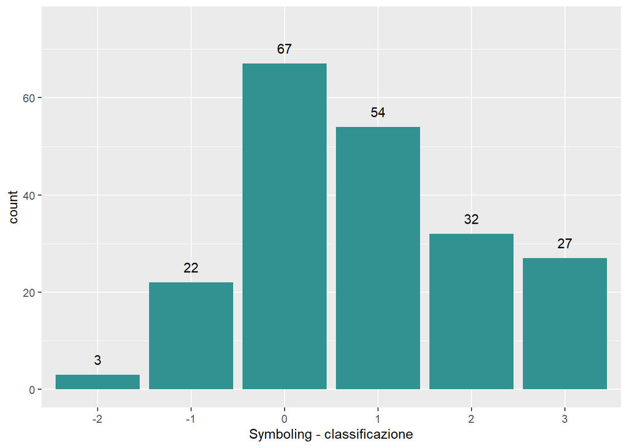

Il symboling o classificazione del rischio, è un sistema che assegna un livello di rischio ad un veicolo con lo scopo di calcolarne il premio assicurativo. In questa scala un punteggio pari a +3 indica il veicolo come “rischioso” mentre -3 “sicuro” da assicurare.

Si può osservare che la maggior parte dei veicoli registrati nel dataset sono stati classificati con un valore di *symboling* pari a 0.

#### *Make*

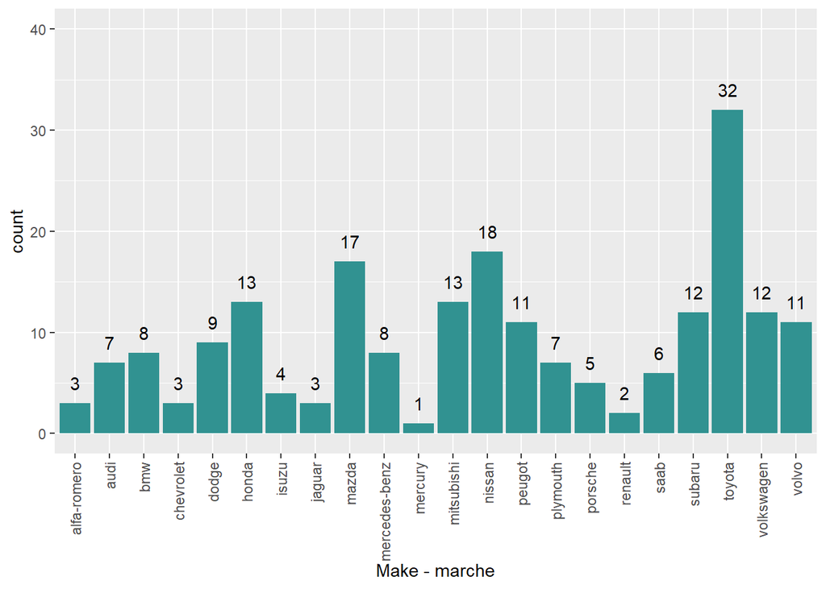

La marca d’auto più presente del dataset è la Toyota.

#### *Fuel type*

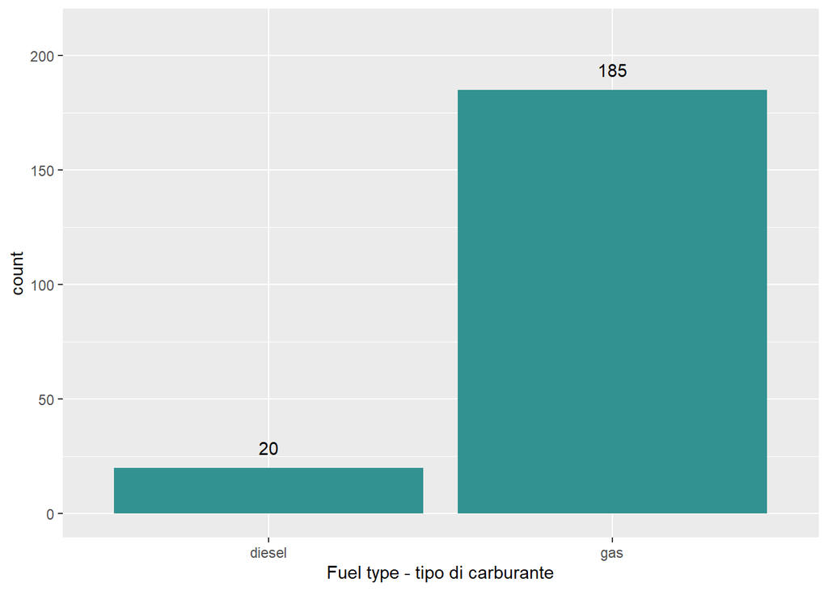

Nel dataset la tipologia di carburante più frequente è la benzina.

#### *Aspiration* & *number of doors*

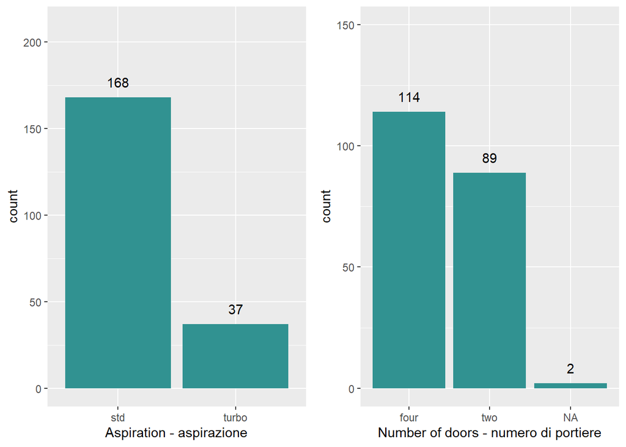

La maggior parte delle auto del dataset ha quattro porte, mentre la tipologia di aspirazione più frequente è la std.

#### *Body style* & *drive wheels*

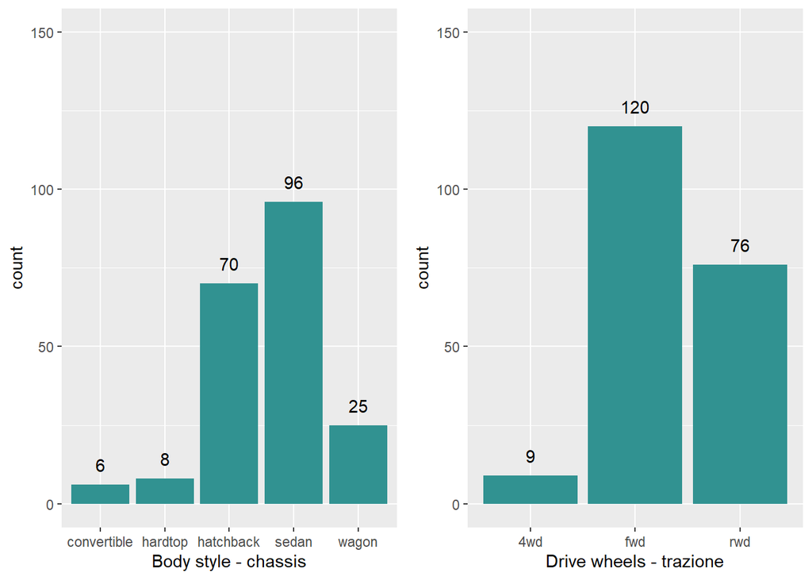

Le auto sono per la maggiore del tipo berlina (sedan) e a trazione anteriore (fwd).

#### *Engine type* & *engine location*

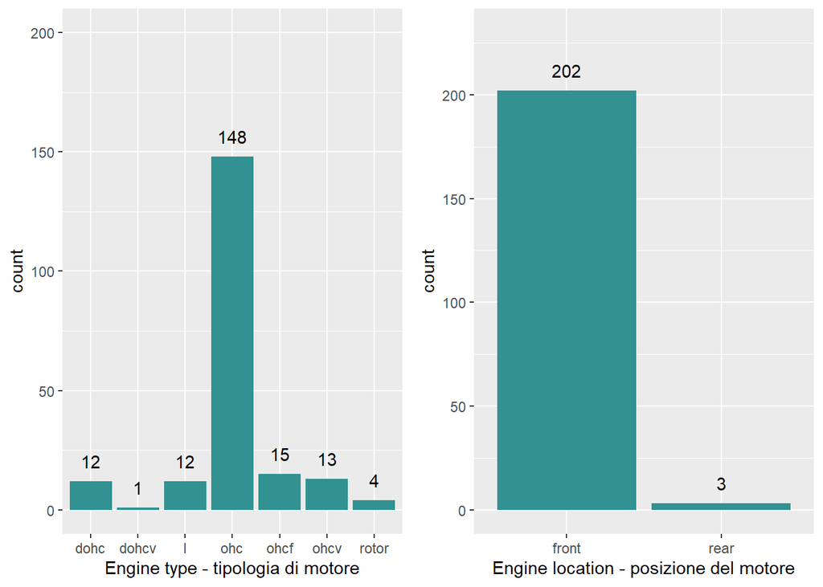

La maggior parte delle automobili hanno il motore nella parte anteriore e di tipologia ohc, ossia motori con alberi a canne in testa.

#### *Fuel system* & *Number of cylinders*

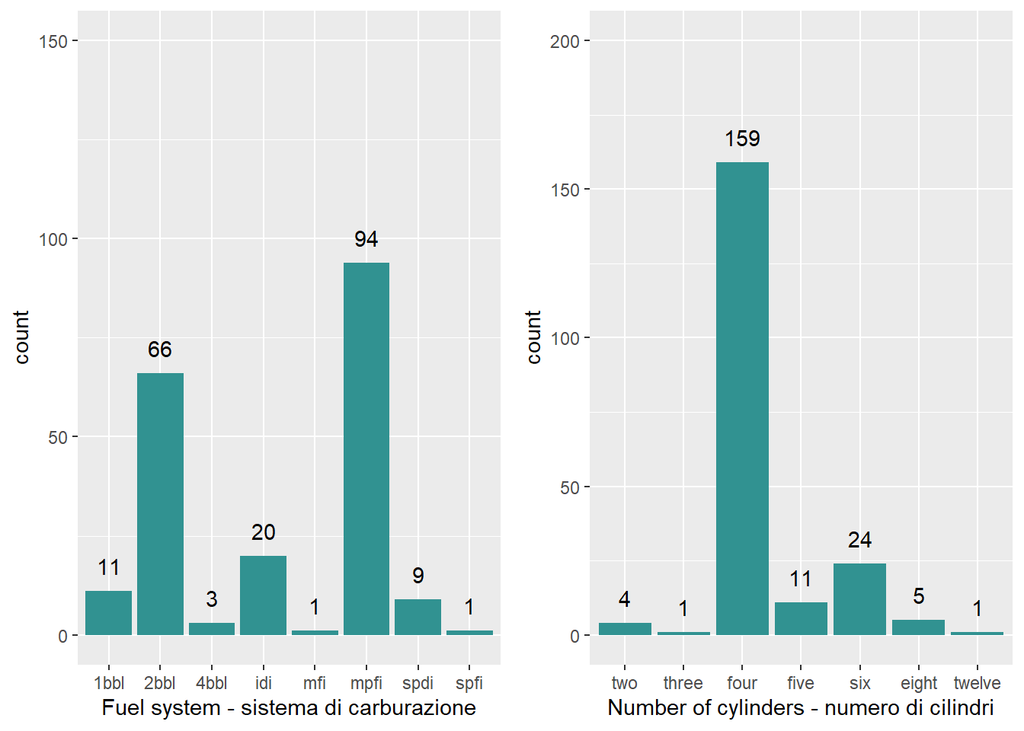

La maggior parte dei motori sono a pistoni a quattro cilindri con un sistema di carburazione del tipo *mpfi*, ossia a iniezione multi-point.

## 2. Analisi univariata - variabili continue

Per le variabili di tipo **continuo**, per poterle analizzare, una possibilità è usare strumenti come **boxplot**, **istogrammi** e **curve di densità**; usandoli insieme, è possibile visualizzare sia in maniera intuitiva (attraverso gli istogrammi e le curve di densità) che in maniera più dettagliata (boxplot) la distribuzione della variabile considerata:

### Misurazioni del motore

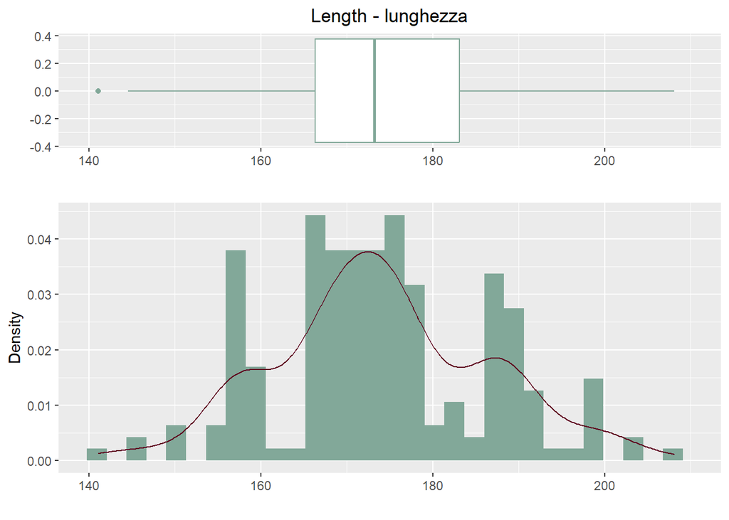

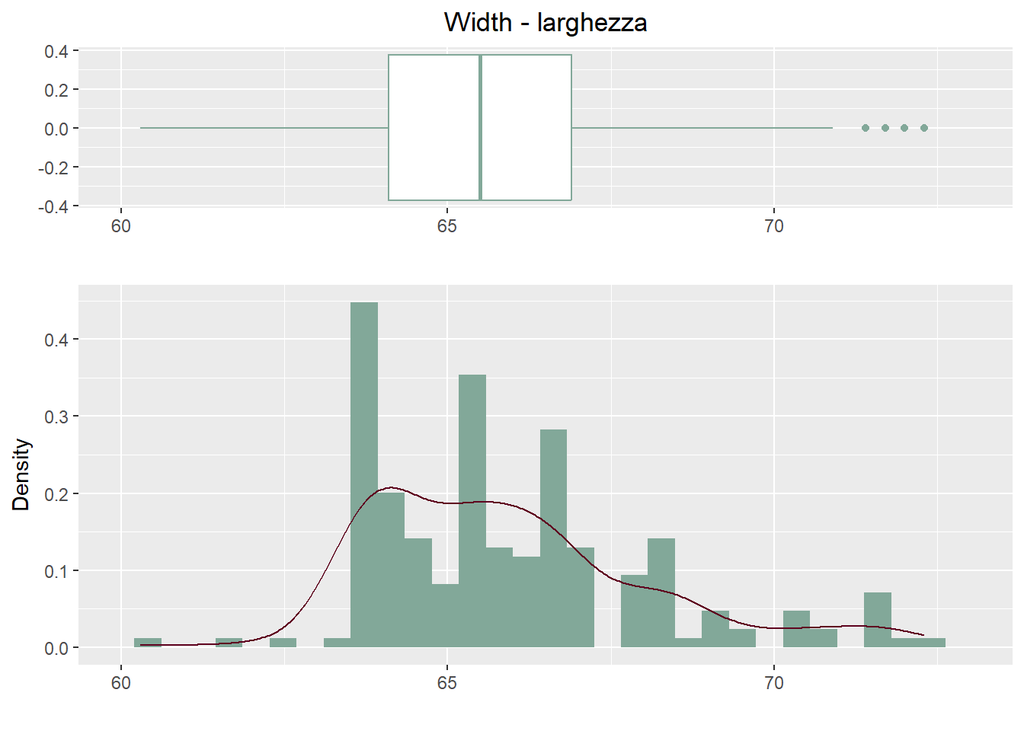

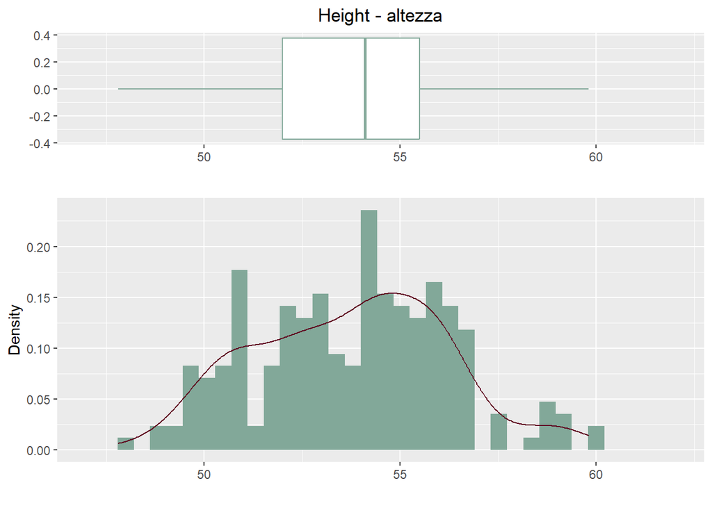

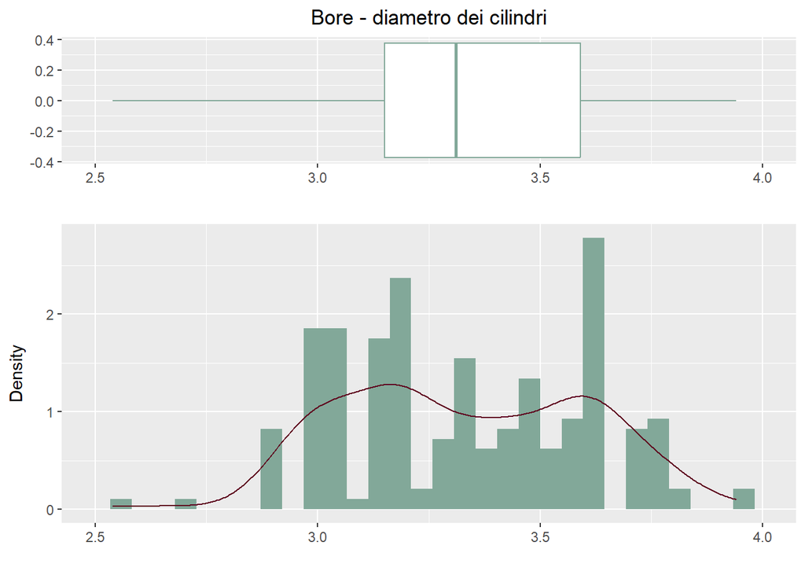

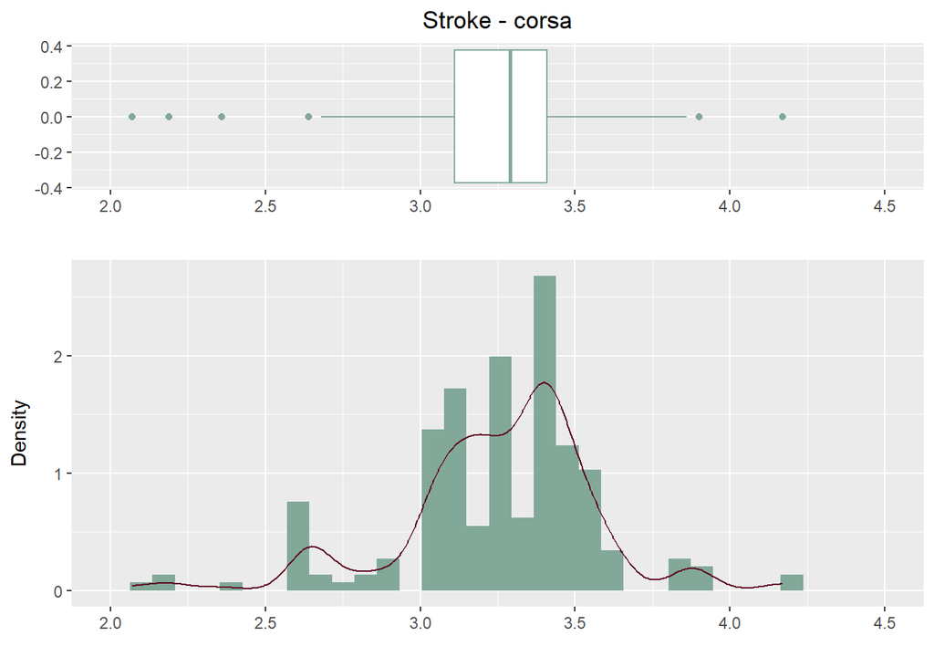

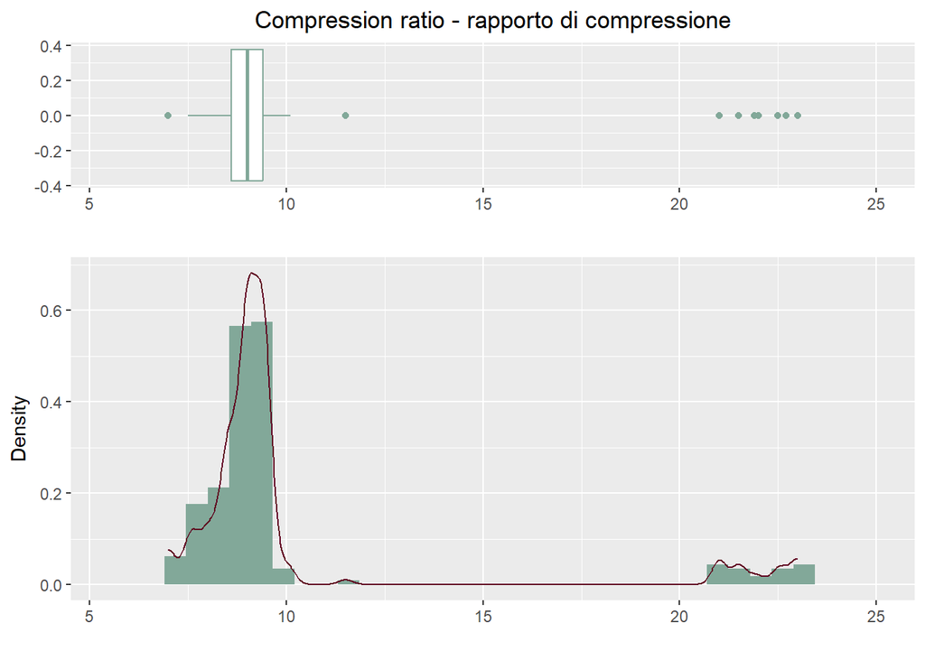

### Caratteristiche dei veicoli

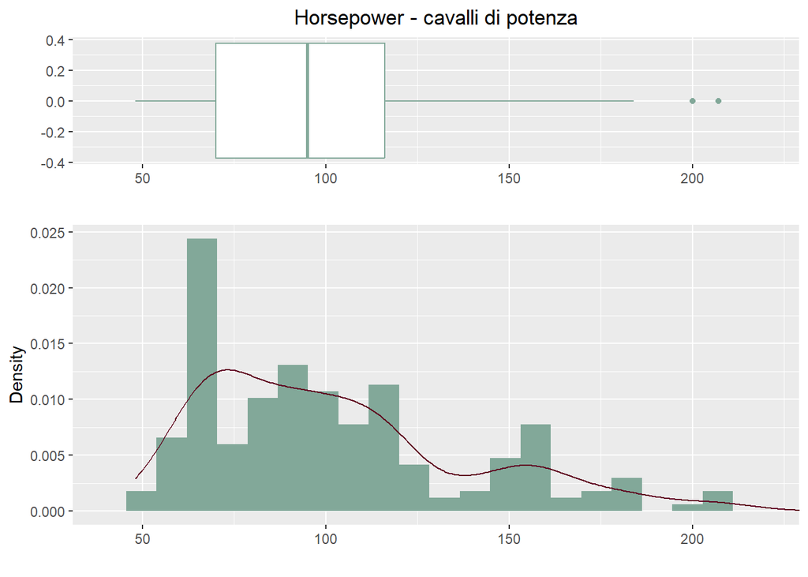

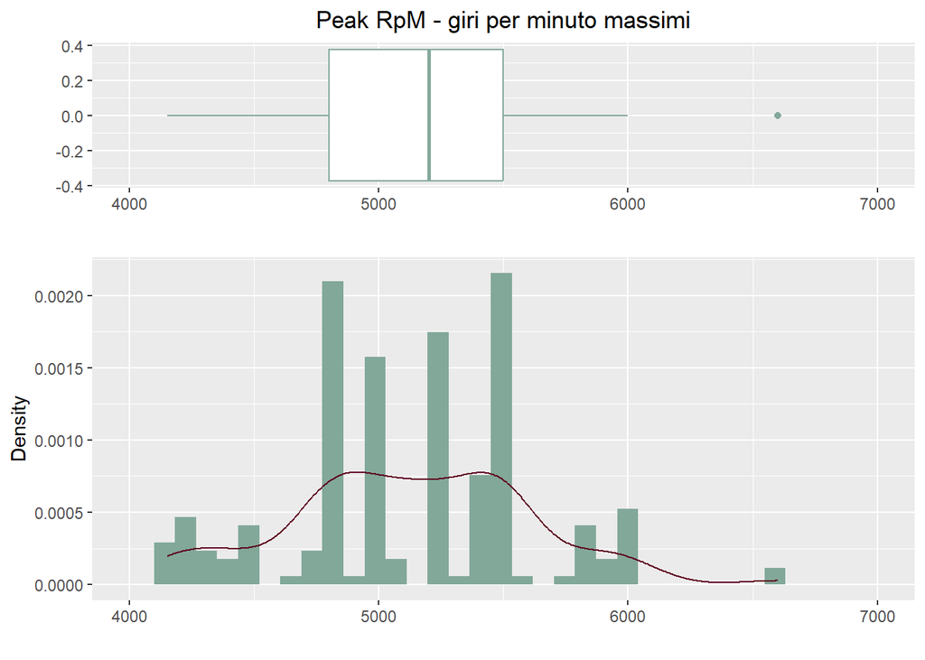

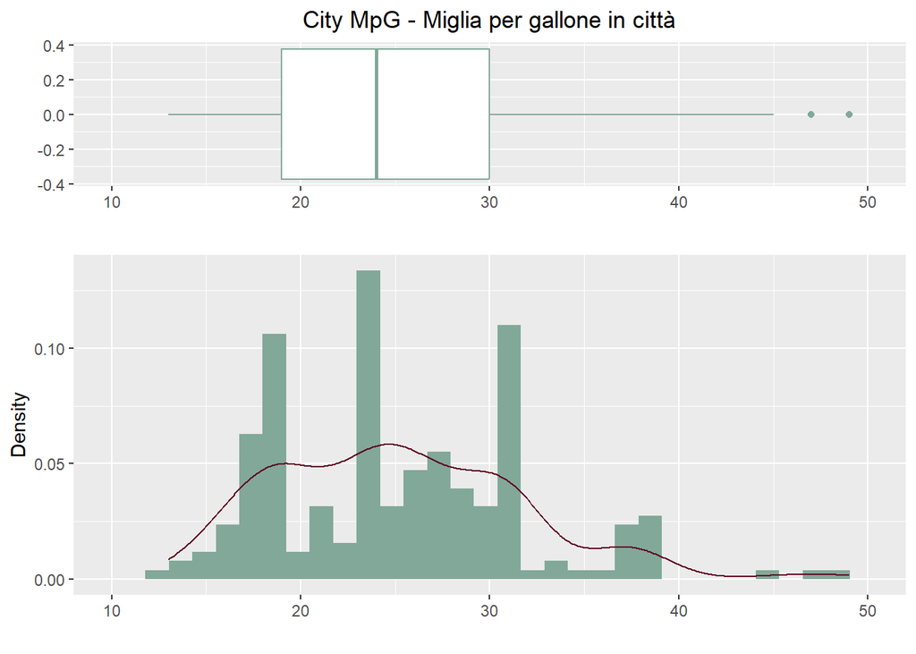

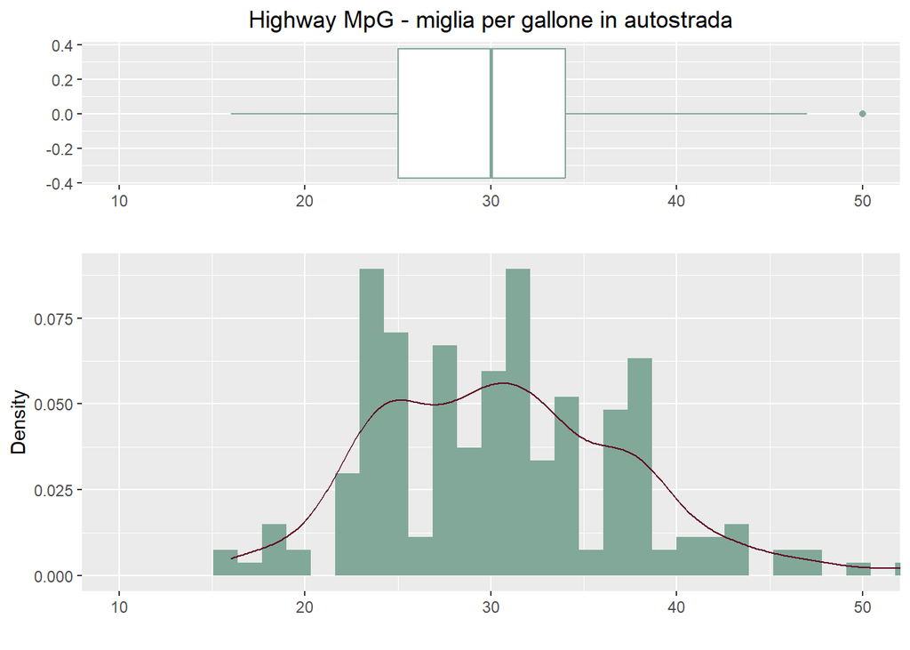

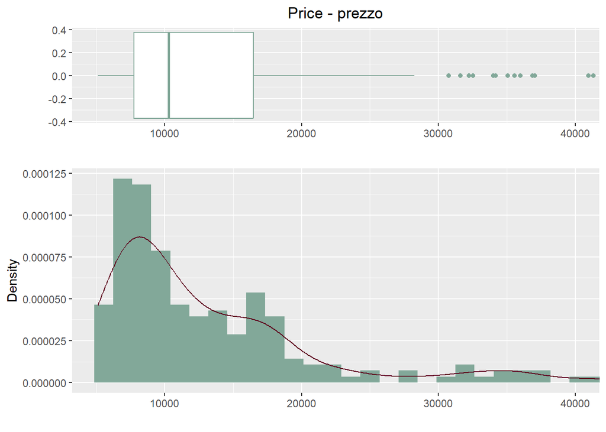

## 3. Analisi bivariata

## Analisi collineare

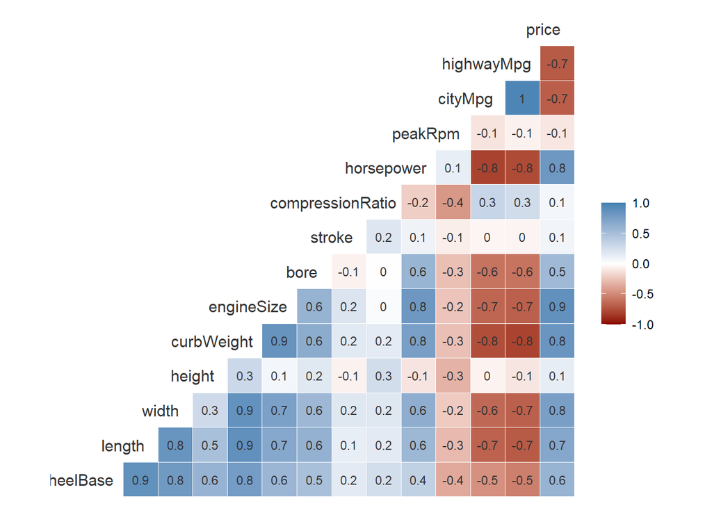

#### *Engine Size e cilindrata*

Una prima analisi si può effettuare rispetto alle variabili *EngineSize* (cilindrata) e le variabili *NumOfCylinders*, *Bore*, *Stroke*.

La variabile *EngineSize* può essere calcolata dalle altre variabili seguendo la formula:

```r
Cylinders = data$numOfCylinders
levels(Cylinders) = c(2, 3, 4, 5, 6, 8, 12)
Cilindrata = pi*(data$bore*2.54/2)^2*data$stroke*2.54*as.numeric(as.character(Cylinders))
```

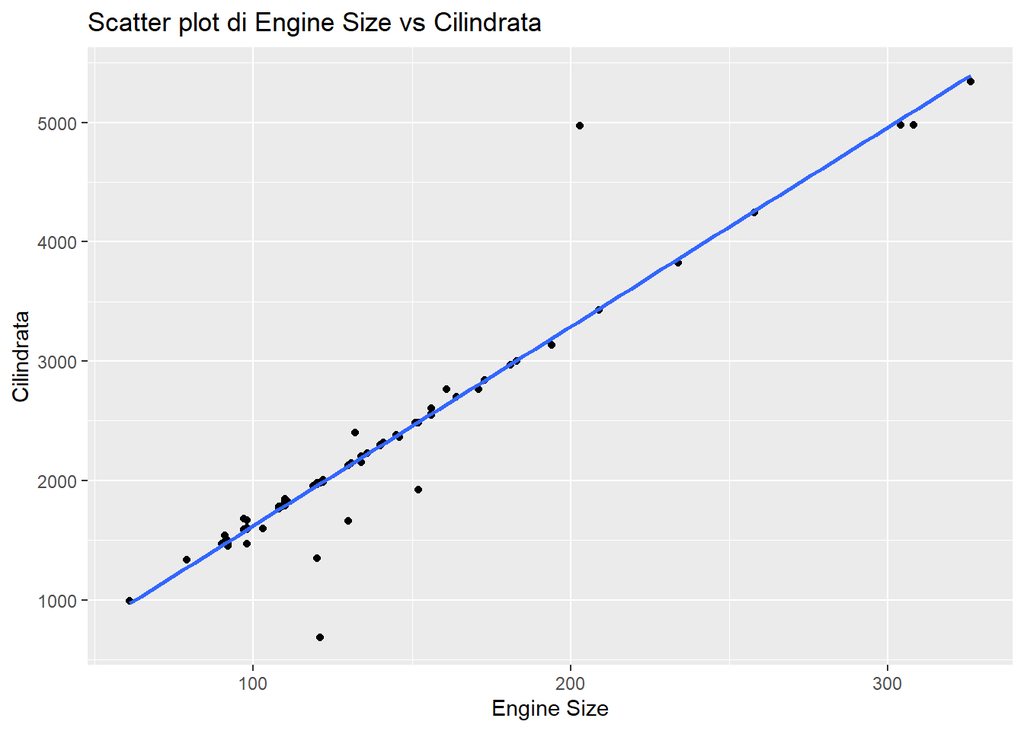

Osserviamo ora le relazioni di *EngineSize* con le altre variabili.

#### *EngineSize con numOfCylinder*

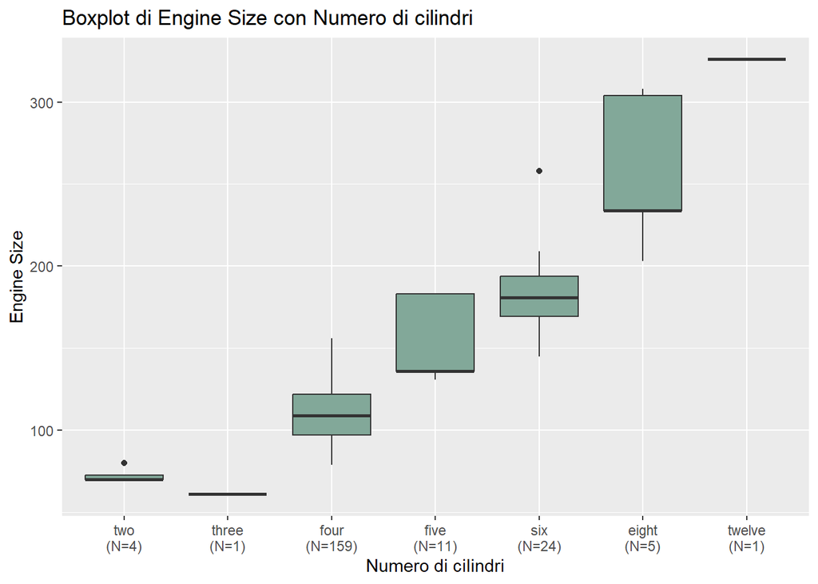

```
##                     Df Sum Sq Mean Sq F value Pr(>F)
## data$numOfCylinder   6 260409   43401   92.06 <2e-16 ***
## Residuals          198  93350     471
## ---
## Signif. codes:  0 '***' 0.001 '**' 0.01 '*' 0.05 '.' 0.1 ' ' 1
```

Il test *ANOVA* suggerisce grande una correlazione di *EngineSize* con il numero di cilindri.

Nel boxplot, infatti, si nota come la variabile *EngineSize* aumenta con l’aumentare dei cilindri.

#### *EngineSize con Bore*

La variabile *EngineSize* aumenta linearmente anche con la variabile *Bore*, che rappresenta il diametro dei cilindri.

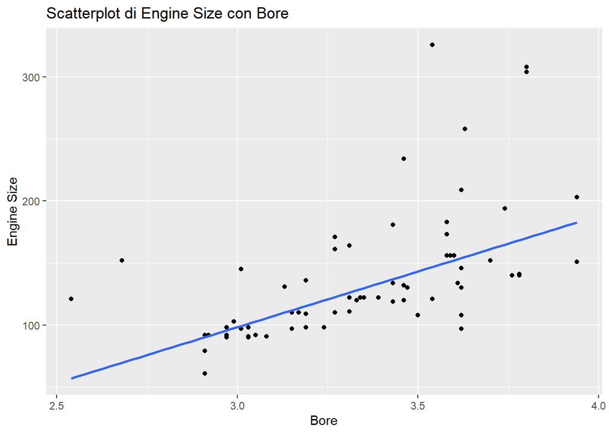

```
##
## Call:
## lm(formula = data$engineSize ~ data$bore)
##
## Residuals:
##     Min      1Q  Median      3Q     Max
## -57.043 -14.856  -7.808   1.687 179.138
##
## Coefficients:
##             Estimate Std. Error t value Pr(>|t|)
## (Intercept) -170.888     28.783  -5.937 1.27e-08 ***
## data$bore     89.760      8.615  10.419  < 2e-16 ***
## ---
## Signif. codes:  0 '***' 0.001 '**' 0.01 '*' 0.05 '.' 0.1 ' ' 1
##
## Residual standard error: 33.33 on 199 degrees of freedom
##   (4 osservazioni eliminate a causa di valori mancanti)
## Multiple R-squared:  0.3529, Adjusted R-squared:  0.3497
## F-statistic: 108.5 on 1 and 199 DF,  p-value: < 2.2e-16
```

Lo scatterplot e il **p-value** del `summary()` mostra come ci sia un’alta correlazione tra le due variabili.

#### *EngineSize con Stroke*

Osserviamo innanzitutto lo scatterplot tra la cilindrata e *Stroke*, ossia l’altezza di ogni cilindro.

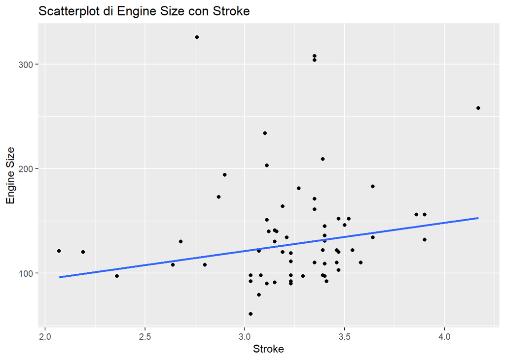

Non sembra esserci un netto aumento della cilindrata con l’aumentare della variabile *stroke*.

```
##
## Call:
## lm(formula = data$engineSize ~ data$stroke)
##
## Residuals:
##     Min      1Q  Median      3Q     Max
## -60.911 -29.911  -9.619  15.853 211.371
##
## Coefficients:
##             Estimate Std. Error t value Pr(>|t|)
## (Intercept)    40.20      29.60   1.358  0.17605
## data$stroke    26.97       9.05   2.980  0.00324 **
## ---
## Signif. codes:  0 '***' 0.001 '**' 0.01 '*' 0.05 '.' 0.1 ' ' 1
##
## Residual standard error: 40.54 on 199 degrees of freedom
##   (4 osservazioni eliminate a causa di valori mancanti)
## Multiple R-squared:  0.04271,    Adjusted R-squared:  0.0379
## F-statistic: 8.879 on 1 and 199 DF,  p-value: 0.003243
```

La correlazione positiva di *EngineSize* con *Stroke*, seppur presente, risulta nettamente inferiore rispetto alle variabili precedenti.

#### Conclusione

Si ritiene che la variabile *EngineSize* sia sufficiente per spiegare le altre variabili presenti nel dataset e che le variabili *NumOfCylinders*, *Bore*, *Stroke* non porterebbero ad alcun miglioramento di un eventuale modello.

Dato che è presente un’alta correlazione con le variabili *numOfCylinder* e *Bore*, risulta essere sensato che esse possano essere sostituite da *EngineSize*.

Nonostante non ci sia una forte correlazione tra le variabili *EngineSize* e *Stroke*, si decide comunque di non considerare la variabile *Stroke*, in quanto, come si può notare facilmente dalla matrice di correlazione proposta precedentemente, essa non spiega bene nessuna delle altre variabili.

Inoltre risulta essere sensato non considerare le variabili *NumOfCylinders*, *Bore*, *Stroke* in quanto *EngineSize* risulta essere un calcolo diretto di quest’ultime.

#### *Compression ratio & fuel type*

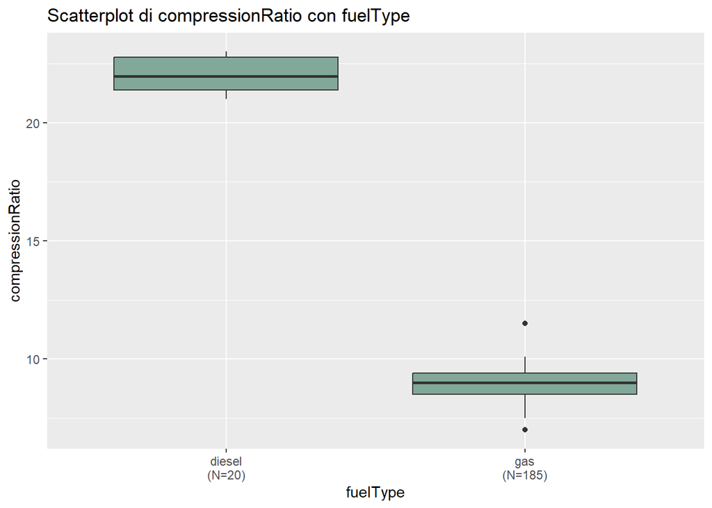

```
##                Df Sum Sq Mean Sq F value Pr(>F)
## data$fuelType   1 3118.6  3118.6    6336 <2e-16 ***
## Residuals     203   99.9     0.5
## ---
## Signif. codes:  0 '***' 0.001 '**' 0.01 '*' 0.05 '.' 0.1 ' ' 1
```

Si può notare come la scelta di *fuelType* porti ad avere un *compressionRatio* nettamente diverso.

Dato che la variabilità del *CompressionRatio* risulta essere bassa, si decide, per semplicità, di tenere solo la variabile *fuelType*.

Passiamo ora all’analizzare la colliearità delle variabili *width*, *length*, *height*, *wheelBase* e *curbWeight*.

#### *length con wheelBase*

Dato che la variabile *wheelBase* indica la distanza tra le ruote anteriori e quelle posteriori, sembra sensato pensare che più è lunga un’auto più questa distanza aumenti. Vediamo ora lo scatterplot:

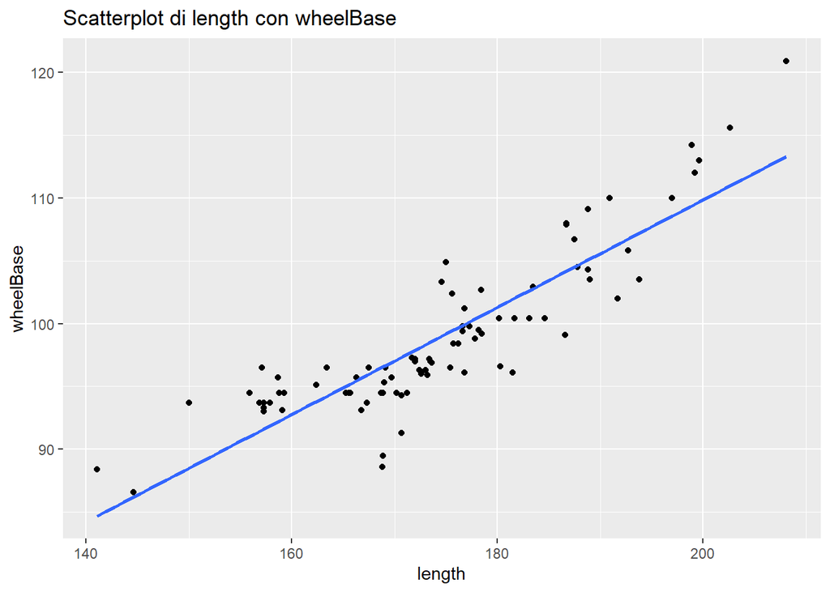

Si può notare come i valori si dispongano molto precisamente su una retta.

```
##
## Call:
## lm(formula = data$wheelBase ~ data$length)
##
## Residuals:
##     Min      1Q  Median      3Q     Max
## -7.9158 -1.6388 -0.5217  2.0934  7.6078
##
## Coefficients:
##             Estimate Std. Error t value Pr(>|t|)
## (Intercept) 24.45804    2.89825   8.439 6.01e-15 ***
## data$length  0.42688    0.01661  25.700  < 2e-16 ***
## ---
## Signif. codes:  0 '***' 0.001 '**' 0.01 '*' 0.05 '.' 0.1 ' ' 1
##
## Residual standard error: 2.927 on 203 degrees of freedom
## Multiple R-squared:  0.7649, Adjusted R-squared:  0.7637
## F-statistic: 660.5 on 1 and 203 DF,  p-value: < 2.2e-16
```

Il **p-value** del `summary()` dà conferma dell’elevata correlazione. Si ha anche un elevato valore dell’**R-quadro** e un valore vicino allo 0 del **Pr(>|t|)** dell’intercetta e del coefficiente. Possiamo dedurre che la variabile *length* spieghi bene la variabile *wheelBase* e possa sostituirla, dato che, di fatto, indica una caratteristica molto simile.

#### *curbWeight con length*

Si considera che, se un’auto risulta essere più lunga rispetto a un’altra, probabilmente essa risulta essere anche più pesante.

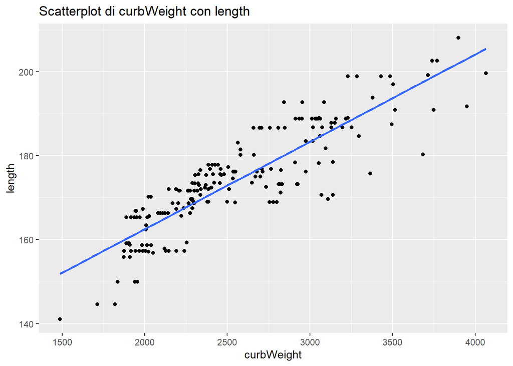

Lo scatterplot conferma la nostra ipotesi. I dati si dispongono in maniera lineare.

```
##
## Call:
## lm(formula = data$length ~ data$curbWeight)
##
## Residuals:
##     Min      1Q  Median      3Q     Max
## -17.239  -3.974   1.174   4.495  12.652
##
## Coefficients:
##                  Estimate Std. Error t value Pr(>|t|)
## (Intercept)     1.209e+02  2.078e+00   58.18   <2e-16 ***
## data$curbWeight 2.080e-02  7.969e-04   26.10   <2e-16 ***
## ---
## Signif. codes:  0 '***' 0.001 '**' 0.01 '*' 0.05 '.' 0.1 ' ' 1
##
## Residual standard error: 5.926 on 203 degrees of freedom
## Multiple R-squared:  0.7704, Adjusted R-squared:  0.7693
## F-statistic: 681.2 on 1 and 203 DF,  p-value: < 2.2e-16
```

Anche in questo caso i valori del **p-value** e dei **Pr(>|t|)** dell’intercetta e del coefficiente angolare risultano essere vicini allo 0, e l’**R-quadro** elevato.

#### *curbWeight con width*

Si considera che, se un’auto risulta essere più larga rispetto a un’altra, probabilmente essa risulta essere anche più pesante.

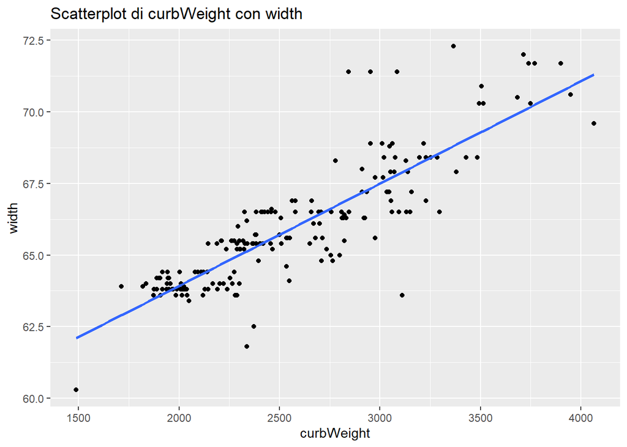

Lo scatterplot conferma la nostra ipotesi. I dati si dispongono in maniera lineare.

```
##
## Call:
## lm(formula = data$width ~ data$curbWeight)
##
## Residuals:
##     Min      1Q  Median      3Q     Max
## -4.2883 -0.5342  0.0372  0.6156  4.4619
##
## Coefficients:
##                  Estimate Std. Error t value Pr(>|t|)
## (Intercept)     5.678e+01  3.757e-01  151.12   <2e-16 ***
## data$curbWeight 3.572e-03  1.441e-04   24.79   <2e-16 ***
## ---
## Signif. codes:  0 '***' 0.001 '**' 0.01 '*' 0.05 '.' 0.1 ' ' 1
##
## Residual standard error: 1.071 on 203 degrees of freedom
## Multiple R-squared:  0.7517, Adjusted R-squared:  0.7505
## F-statistic: 614.7 on 1 and 203 DF,  p-value: < 2.2e-16
```

Anche in questo caso i valori del **p-value** e dei **Pr(>|t|)** dell’intercetta e del coefficiente angolare risultano essere vicini allo 0, e l’**R-quadro** elevato.

#### *curbWeight con height*

Si considera che, se un’auto risulta essere più alta rispetto a un’altra, probabilmente essa risulta essere anche più pesante.

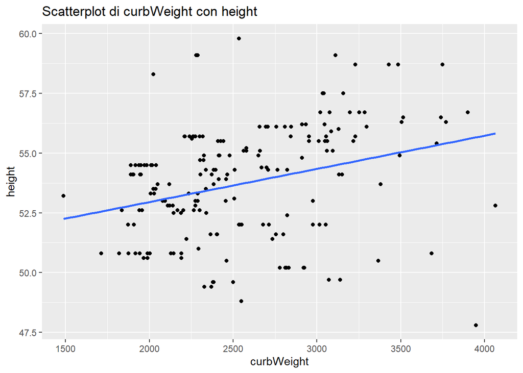

Lo scatterplot non sembra confermare con certezza la nostra ipotesi. I dati si dispongono in maniera piuttosto casuale, anche se si può comunque notare una correlazione positiva.

```
##
## Call:
## lm(formula = data$height ~ data$curbWeight)
##
## Residuals:
##     Min      1Q  Median      3Q     Max
## -7.8591 -1.9032  0.4748  1.5222  6.1036
##
## Coefficients:
##                  Estimate Std. Error t value Pr(>|t|)
## (Intercept)     5.018e+01  8.206e-01  61.152  < 2e-16 ***
## data$curbWeight 1.387e-03  3.147e-04   4.408 1.69e-05 ***
## ---
## Signif. codes:  0 '***' 0.001 '**' 0.01 '*' 0.05 '.' 0.1 ' ' 1
##
## Residual standard error: 2.34 on 203 degrees of freedom
## Multiple R-squared:  0.08736,    Adjusted R-squared:  0.08287
## F-statistic: 19.43 on 1 and 203 DF,  p-value: 1.688e-05
```

Il valore del **p-value** risulta essere minore di 0.05, mostrando come ci sia una correlazione, anche se non elevata.

#### *Volume*

Si può anche fare un’approssimazione del volume di un’auto e metterlo in relazione alla massa.

```r
volume = data$height*data$length*data$width
```

Si mostra ora lo scatterplot:

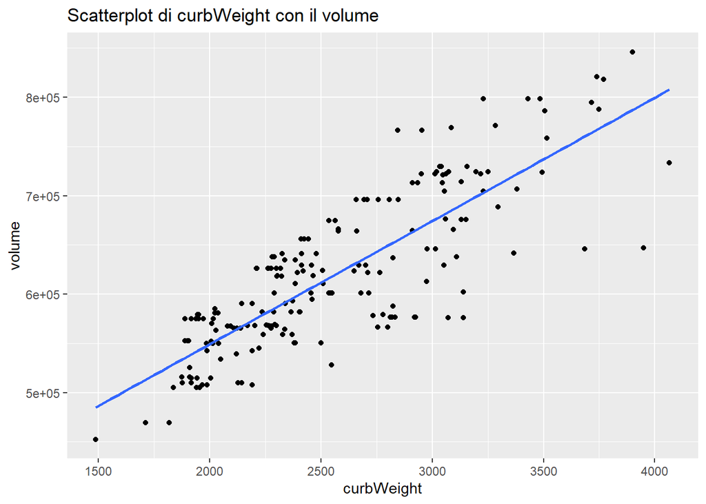

```
##
## Call:
## lm(formula = volume ~ data$curbWeight)
##
## Residuals:
##     Min      1Q  Median      3Q     Max
## -146256  -26988     999   37300  111558
##
## Coefficients:
##                  Estimate Std. Error t value Pr(>|t|)
## (Intercept)     2.990e+05  1.600e+04   18.69   <2e-16 ***
## data$curbWeight 1.251e+02  6.134e+00   20.40   <2e-16 ***
## ---
## Signif. codes:  0 '***' 0.001 '**' 0.01 '*' 0.05 '.' 0.1 ' ' 1
##
## Residual standard error: 45620 on 203 degrees of freedom
## Multiple R-squared:  0.6721, Adjusted R-squared:  0.6705
## F-statistic: 416.1 on 1 and 203 DF,  p-value: < 2.2e-16
```

Si può notare come sia presente una forte correlazione.

#### Conclusione

È evidente che le variabili *length* e *wheelBase* mostrano una forte correlazione e forniscono informazioni simili nelle analisi statistiche. Pertanto si ha una collinearità delle due variabili.

Analogamente, sebbene ci sia siano degli scarti non trascurabili nel modello lineare, sembra esserci collinearità tra le variabili *width*, *length* e la variabile *curbWeight*. Nonostante le variabili descrivano caratteristiche diverse di un’auto, la larghezza e la lunghezza di un veicolo tendono ad influenzare direttamente il suo peso a vuoto secondo uno schema lineare. Si decide quindi di tenere la variabile *curbWeight*.

Infine, si osserva che non è presente una collinearità tra *height* e *curbWeight* in quanto le caratteristiche descritte sono diverse e non è presente una netta linearità tra le due variabili.

#### *highwayMpg e cityMpg*

Passiamo ora all’analizzare la collinearità delle variabili *cityMpg* e *highwayMpg*. Si pensa che se un’auto consuma molto in città, consumerà molto anche in autostrada.

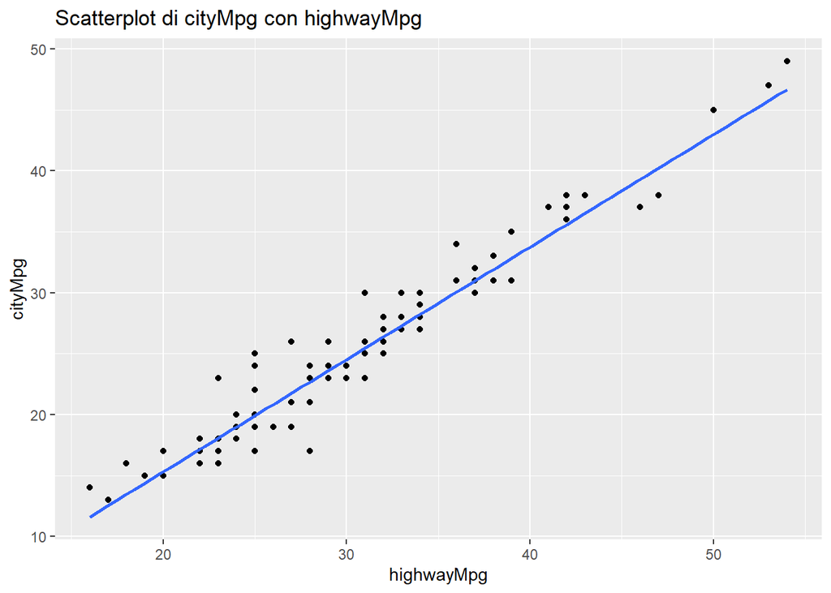

```
##
## Call:
## lm(formula = data$cityMpg ~ data$highwayMpg)
##
## Residuals:
##     Min      1Q  Median      3Q     Max
## -5.6808 -0.9124 -0.2174  0.7054  5.0876
##
## Coefficients:
##                 Estimate Std. Error t value Pr(>|t|)
## (Intercept)     -3.15689    0.49941  -6.321 1.62e-09 ***
## data$highwayMpg  0.92277    0.01585  58.221  < 2e-16 ***
## ---
## Signif. codes:  0 '***' 0.001 '**' 0.01 '*' 0.05 '.' 0.1 ' ' 1
##
## Residual standard error: 1.559 on 203 degrees of freedom
## Multiple R-squared:  0.9435, Adjusted R-squared:  0.9432
## F-statistic:  3390 on 1 and 203 DF,  p-value: < 2.2e-16
```

Si nota dallo scatterplot come i dati si dispongano in una retta.

Il valore **p-value** e dei **Pr(>|t|)** dell’intercetta e del coefficiente angolare risultano essere vicini allo 0 e l’**R-quadro** molto elevato.

Si può dedurre che le due variabili spieghino di fatto la stessa caratteristica e che dunque sia presente una collinearità tra le due variabili.

Si decide dunque di tenere la variabile *cityMpg* in quanto lo si ritiene un dato più rilevante nella scelta di acquisto di un’auto per un individuo medio.

### Analisi bivariata rispetto alla variabile *price*

Oltre all’analisi univariata, è interessante considerare anche il rapporto che c’è tra coppie di variabili attraverso strumenti come i boxplot e diversi test statistici, introducendo l’analisi con una matrice di correlazione:

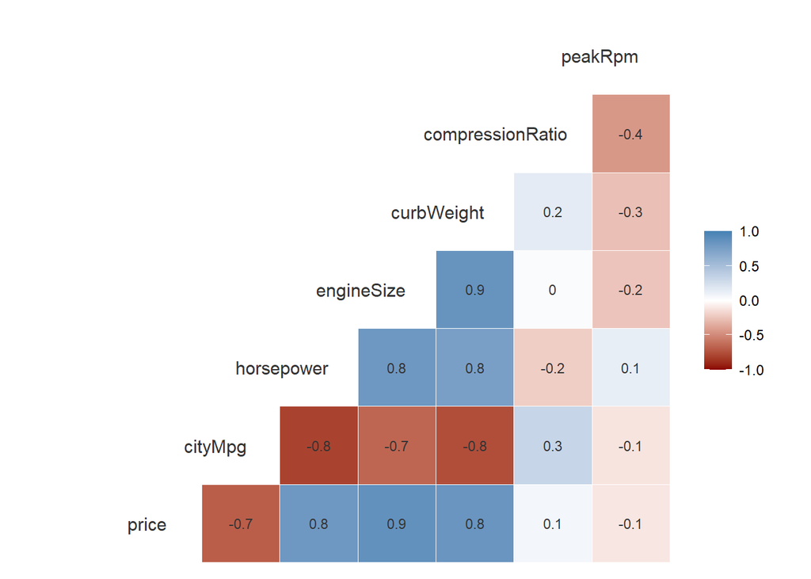

Della matrice ci concentriamo soprattutto sulla variabile *price* e come essa correli con le altre variabili.

Si può notare che la variabile *cityMpg* è correlata negativamente con il prezzo $(-0.7)$. Facendo una prima ipotesi si può supporre che all’aumentare dei consumi aumenti anche il prezzo dell’auto.

Un’altra forte correlazione si nota con la variabile *horsepower* $(0.8)$ e con engineSize $(0.9)$. Queste sono caratteristiche del motore e pare logico pensare che all’aumentare della potenza o della dimensione del motore aumenti anche il prezzo dell’auto.

Infine ci sono le variabili che dipendono di più dalla struttura dell’auto, come *height* $(0.1)$, *length* $(0.7)$ e *width* $(0.8)$. Di queste la variabile più esplicativa sembra però *curbWeight* $(0.8)$. Quindi sembra che all’aumentare del peso (e di conseguenza delle dimensioni) dell’auto, il prezzo aumenti.

### Boxplot condizionati

Dopo aver analizzato superficialmente le variabili numeriche in una matrice di correlazione, ci concentriamo sulle variabili categoriali e come esse interagiscano con la variabile *price*. Un modo efficacie per farlo è certamente lo studio attraverso dei Boxplot condizionati, in cui viene considerato il legame tra una variabile numerica rispetto ad una variabile categoriale, per vedere come si distribuisce rispetto ai diversi livelli.

#### *price ~ symboling*

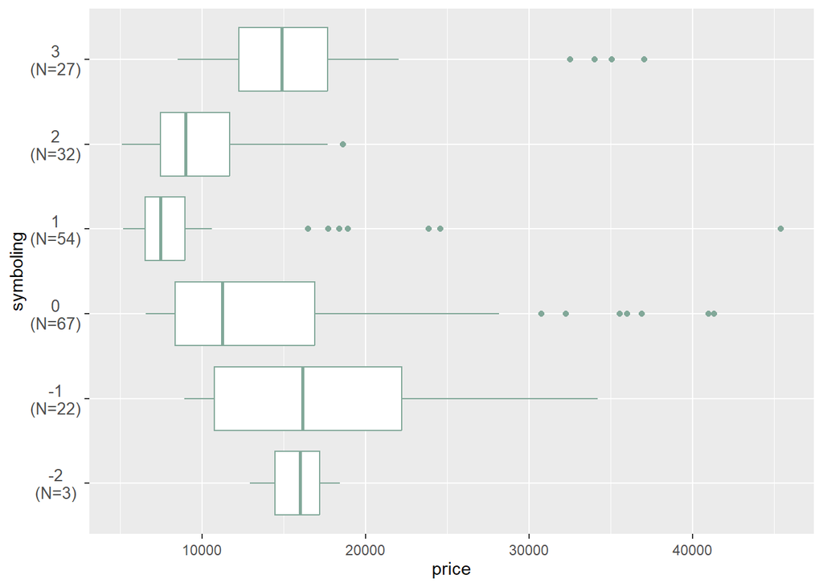

Dal grafico si vede che con il discostarsi dai valori centrali il prezzo tende ad aumentare, inoltre:

```
##              Df    Sum Sq   Mean Sq F value   Pr(>F)
## symboling     5 1.887e+09 377325630   6.848 6.56e-06 ***
## Residuals   195 1.074e+10  55100228
## ---
## Signif. codes:  0 '***' 0.001 '**' 0.01 '*' 0.05 '.' 0.1 ' ' 1
## 4 osservazioni eliminate a causa di valori mancanti
```

Il test *ANOVA* conferma una dipendenza della variabile *symboling* alla variabile *price*.